# Classifying New York City Neighborhoods: A Data-Driven Approach to Urban Typologies

Author

Sunduss Hamdan and Kaela Girod

## 1. Introduction

New York City is one of the most unequal cities in the United States. While some neighborhoods are home to some of the wealthiest residents in the world, others face persistent poverty, limited job opportunities, and inadequate access to resources. Despite this stark divide, policymakers tasked with deciding where to direct funding and interventions often rely on a single measure, such as average income or the share of residents living below the poverty line, to characterize neighborhoods and determine need. The problem with this approach is that it flattens the complexity of what makes neighborhoods genuinely different from one another. A neighborhood with a high poverty rate but stable housing, good transit, and strong employment access is a very different place from one with the same poverty rate but high vacancy, poor connectivity, and limited opportunity. Treating them the same way leads to poorly targeted policies. This project takes a different approach: we use data-driven methods, specifically using two dimension reduction techniques (Principle Component Analysis and Generalized Low Rand Models) along with two clustering techniques (K-Means Clustering and Gaussian Mixture Modeling) to identify distinct neighborhood typologies across New York City’s census tracts, asking what combinations of demographic and economic characteristics define them.

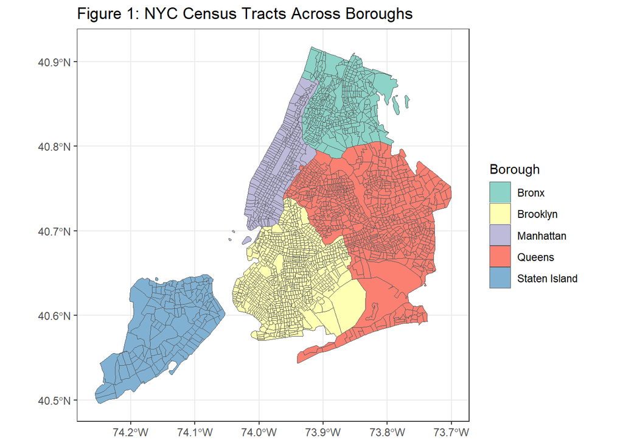

## 2. Background, Policy Relevance, and Literature

New York City’s inequality is well documented. The top three percent of wage earners in the city have seen their incomes grow substantially, while low-wage workers have faced increasing risk of poverty (Center for New York City Affairs, 2024). This inequality is not just economic, it is also deeply racial. The New York City Comptroller (2023) reports that the racial wealth gap in New York is among the most pronounced of any major American city, with Black and Hispanic residents significantly less likely to own homes, hold financial assets, or access higher-paying jobs than their white counterparts. These disparities do not play out evenly across the city; they are concentrated in particular neighborhoods, making the neighborhood itself a critical unit of analysis for anyone interested in understanding or addressing inequality in New York City.

Despite this, the tools that policymakers most commonly use to identify and target disadvantaged neighborhoods remain blunt. Relying on a single indicator like median income or the poverty rate to decide where to direct resources misses the fact that neighborhoods can be disadvantaged in very different ways. A neighborhood with high poverty but stable housing and good transit access has different needs, and different strengths, than one with similar poverty levels but high vacancy rates, poor connectivity, and a declining population. Effective place-based policy requires a more nuanced understanding of what makes each neighborhood distinct.

The academic literature on neighborhood classification offers a more rigorous alternative. Scally et al. (2021) used data-driven classification methods to identify distinct typologies among rural census tracts across the United States, grouping communities by their combinations of characteristics rather than by any single measure. Their central insight, that communities cluster into meaningfully different types, and that policymakers should act on that structure, forms the foundation of our approach. While their work focused on rural America, the core logic translates directly to an urban setting: New York City’s neighborhoods are no more uniform than rural communities, and a typology-based approach offers the same potential to improve how investments are targeted.

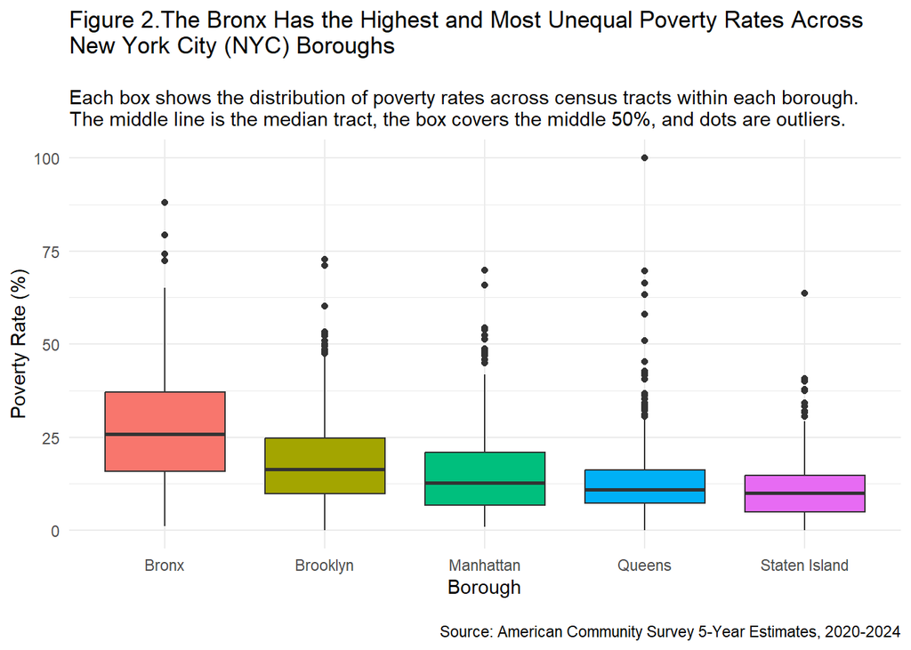

## 3. Data and Variable Selection

Our primary dataset comes from the 2020–2024 American Community Survey (ACS) 5-year estimates, which we access via the Census Bureau API at the census tract level across all five boroughs of New York City. The ACS 5-year estimates pool responses collected over a five-year period, making them the most reliable source of small-area data for geographies as granular as census tracts. Following Scally et al. (2021), we select variables across seven thematic dimensions - economic conditions, educational attainment, housing, racial and ethnic composition, mobility, crime, and social infrastructure - to capture what makes neighborhoods genuinely distinct from one another, rather than relying on any single measure like income or poverty alone.

Many ACS variables are provided as raw counts, which reflect tract population size as much as neighborhood character. We therefore convert these to shares or rates. For example, expressing the number of residents below the poverty line as a proportion of all residents for whom poverty status is determined. Two variables, median household income and median gross rent, are kept as dollar values since they are already directly comparable across tracts. Mean commute time is calculated by dividing total travel time (B08013) by the number of workers aged 16 and over who commute outside the home (B08012), which is consistent with the Census Bureau’s own approach to computing this measure.

We considered but decided to exclude two variables. First, the Gini coefficient (B19083), which measures income inequality within a tract, was dropped because it captures information already covered by our combination of median income and poverty rate. Second, age structure variables (B01001) were excluded because including multiple age-by-sex breakdown columns would add complexity without adding interpretive value; educational attainment serves as a cleaner proxy for the working-age population. Both decisions follow a simple guiding principle: where two variables tell essentially the same story, we keep the one that is easier to interpret in a policy context.

We also wanted to consider a variable related to neighborhood safety as represented by crime. Ideally, we would have liked to use a crime rate by census tract variable. However, since that was not available, we decided to use NYPD Arrests data from the NYC Open Data Portal to calculate the number of arrests by census tract. We used arrests instead of shootings because arrests also captures information on non-gun related violence and crimes, which may also contribute to the perception of safety in a neighborhood. To match arrests to census tracts, we also used the 2020 Census Centers of Population and identified arrests within 800 meters of the population center of the tract. We did this method as opposed to joining based on polygon geometry to more accurately capture the population’s experience of crime, which is not strictly limited by census tract borders.

Additionally, we capture other non-residential characteristics with four more variables. Using NYC Open Data on school points, we similarly count the number of schools within 800 meters of the population center of the tracts. We also use data from the Third Place Index, which measures access to social infrastructure across the US. For New Tork City census tracts, we considered the number of parks, places to eat food and beverages, and traditional retail locations. Since we are not using coverage based data to get a sense of how land is used across the city, these variables will provide some additional information about the social infrastructure present in the census tract if it is not primarily residential.

Finally, in addition to our primary ACS 2020–2024 dataset, we also extract the 2018–2022 ACS 5-year estimates for the same tracts. This allows us to compute four supplementary change variables in median income, median rent, poverty rate, and unemployment rate, that measure how conditions shifted between the two periods. One limitation worth noting is that because both ACS vintages include data collected between 2020 and 2022, they share three overlapping years of data. This means the change variables capture a narrower window of genuine change than the four-year gap between the vintage endpoints might suggest. This is a structural feature of ACS 5-year estimates rather than a choice we made, and we flag it as a limitation of our approach.

Our 22 modeling variables are used as inputs to our dimensionality reduction and clustering models. The list of variables is included in Table 1 below.

Table 1: Variable Selection and Justification

| Dimension | Variable | Construction | Justification |
| --- | --- | --- | --- |
| Economic | Poverty rate | 100*Pop. below poverty line / poverty universe total | Core deprivation indicator; directly named in proposal |
| Economic | Unemployment rate | 100*Unemployed civilians / civilian labor force | Captures labor market exclusion distinct from income poverty |
| Economic | Median household income | Level (dollars) | Primary measure of economic resources; retained as level as it is already comparable across tracts |
| Education | Bachelor’s degree share | 100*Bachelor’s holders / pop. 25+ | Captures human capital; strongly associated with neighborhood economic trajectory |
| Education | Number of Schools | Total number of schools within 800 meters of population center | Captures access to educational facilities to improve human capital |
| Housing | Median gross rent | Level (dollars) | Directly named in proposal; key measure of housing cost |
| Housing | Median home value | Level (dollars) | Complements rent; distinguishes owner- vs. renter-dominated neighborhoods |
| Housing | Renter-occupied share | 100*Renter units / total occupied units | Tenure structure is a fundamental dimension of NYC neighborhood type |
| Housing | Vacancy rate | 100*Vacant units / total housing units | Indicator of disinvestment; key differentiator between declining and stable neighborhoods |
| Race/Ethnicity | Share White | 100*White alone / total population | Captures racial composition; connected to NYC’s documented racial wealth gap |
| Race/Ethnicity | Share Black | 100*Black alone / total population | As above |
| Race/Ethnicity | Share Hispanic | 100*Hispanic or Latino / total population | As above, captures ethnicity composition |
| Race/Ethnicity | Share foreign-born | 100*Foreign-born / total population | NYC’s immigrant geography is a major structural driver of neighborhood type |
| Mobility | Mean commute time | Aggregate travel time / commuting workers 16+ | Directly named in proposal; proxy for transit access and economic integration |
| Crime | Number of Arrests | Total number of arrests within 800 meters of population center | Captures information on neighborhood safety |
| Social Infrastructure | Number of Parks | Total number according to Third Place Index | Captures information about the presence of non-residential activity |
| Social Infrastructure | Number of Food/Beverage Places | As above | As above |
| Social Infrastructure | Number of Retail Locations | As above | As above |
| Change | Change in median income | % change, 2022-2024 vintages | Captures change over time |
| Change | Change in median rent | % change, 2022-2024 vintages | As above |
| Change | Change in poverty rate | Percentage point change | As above, percentage point change is appropriate for rates |
| Change | Change in unemployment | Percentage point change | As above |

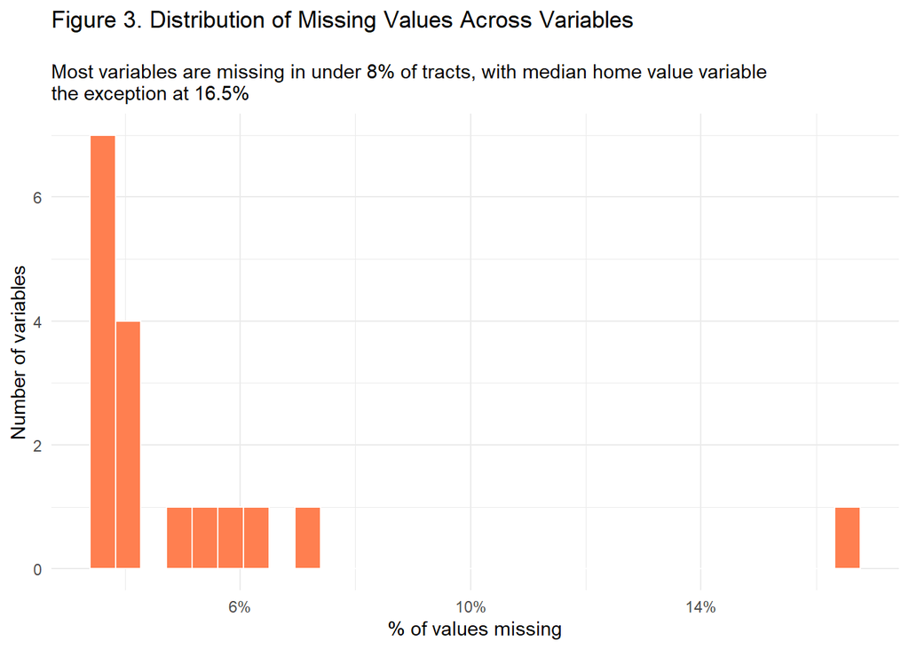

## 4. Methodology

Our analysis compares two methods of clustering census tracts. The first method uses Principal Component Analysis (PCA) for dimension reduction and K-means clustering to compare for the final classification. The second method uses Generalized Low Rank Models (GLRM) to reduce the complexity of our data, followed by Gaussian Mixture Modeling (GMM) for clustering neighborhood groups. Each step is described below.

### 4.1 Method 1

#### 4.1.1 Dimension Reduction with PCA

We begin with 22 variables across seven thematic dimensions. Many of these variables are likely to be correlated with one another. For example, poverty rate and unemployment rate tend to move together, as do median income and bachelor’s degree share. When highly correlated variables are fed directly into a clustering algorithm, they effectively get counted twice, overweighting the dimension of variation they share and distorting the resulting groups.

To address this, we use Principal Component Analysis (PCA) before clustering. PCA takes our 22 variables and transforms them into a smaller set of new variables called principal components. Each component is a weighted combination of the original variables, and the components are constructed so that they are uncorrelated with one another. The first component captures the largest share of overall variation in the data, the second captures the next largest share, and so on. Together, a small number of components can often represent most of the information in the original data with much less redundancy. Because our variables are measured in very different units (dollars, percentages, minutes) we normalize all variables in our PCA recipe so that no single variable dominates due to its scale alone.

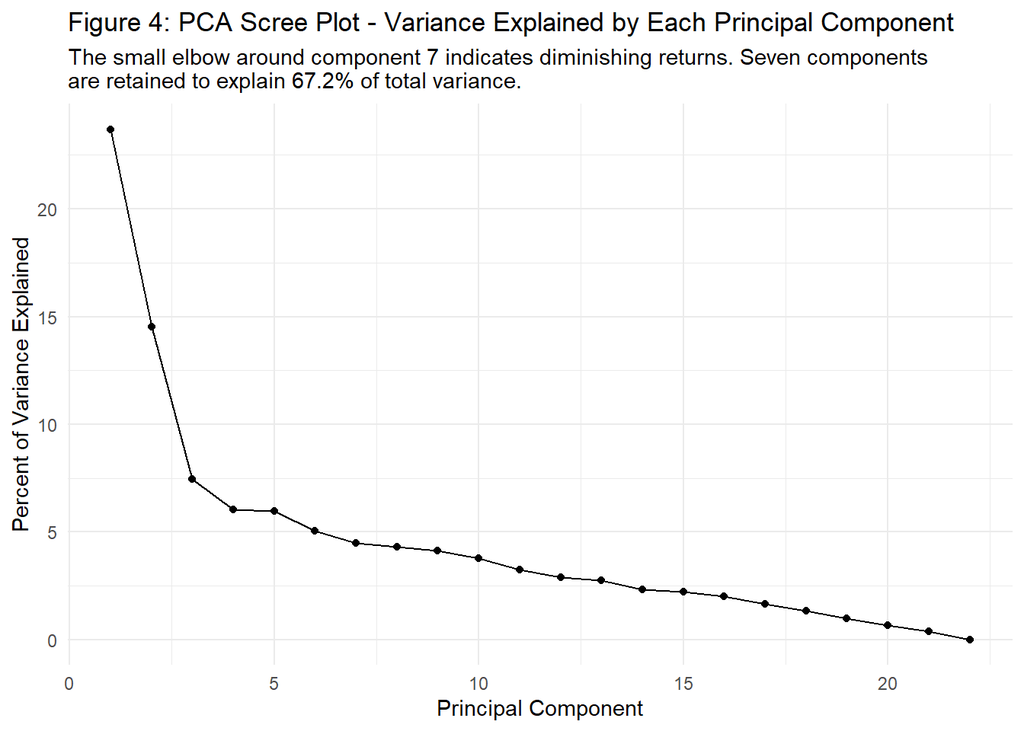

#### 4.1.2 K-Means Clustering

We use K-means clustering as our clustering step with this simpler method. K-means works by grouping census tracts into a fixed number of clusters, where each tract is assigned to the cluster whose center (called the centroid) it is closest to.

The algorithm works as follows: 1. A set of K centroids are placed randomly in the data space  
2. Each tract is assigned to its nearest centroid based on Euclidean distance  
3. The centroids are recalculated as the mean of all tracts assigned to them  
4. Steps 2 and 3 repeat until no tracts change cluster

Because the starting positions of the centroids are random, the results of K-means are not fully deterministic, running the algorithm twice can produce different solutions. We address this by using 100 random starts (`nstart = 100`) and setting a seed to determine the best solution.

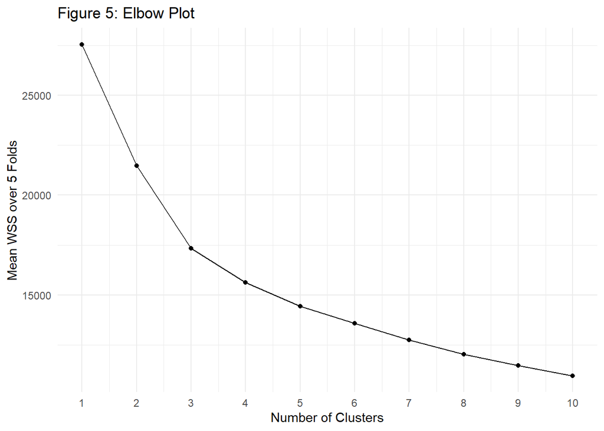

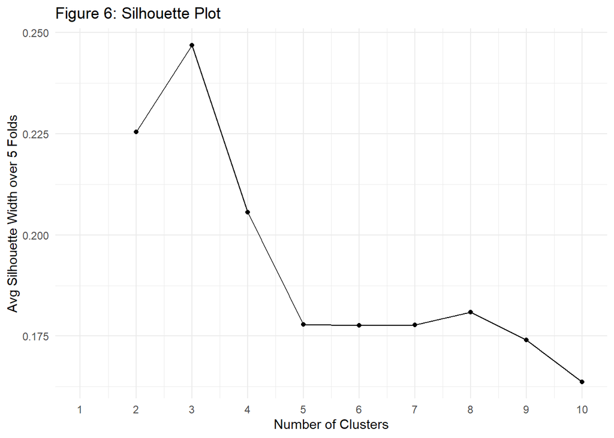

We note two important limitations of K-means. First, it assigns every tract to exactly one cluster with no measure of uncertainty; a tract that sits on the boundary between two neighborhood types is treated the same as one that sitssquarely in the middle of a cluster. Second, as Milechin et al. (2024) found in a closely related study, the statistically optimal number of clusters and the most interpretable number are not always the same. Therefore, we do not automatically accept the statistically optimal number of clusters.

#### 4.2.1 Dimension Reduction with Generalized Low Rank Modeling

Our seond dimension reduction method is Generalized Low Rank Models (GLRM), implemented using library(h2o). Unlike Principle Component Analysis, which is limited to numeric data and assumes linear relationships between variables, GLRM is a more flexible approach that can handle mixed data types, including numeric, categorical, ordinal, and boolean variables. This matters for our project because our dataset includes a mix of continuous measures like median income and rates like poverty rate, alongside count-based variables like arrest rate.

GLRM works by decomposing our original data matrix into two smaller matrices, referred to as X and Y. The matrix X represents each census tract projected onto a smaller dimensional space, and the matrix Y represents each variable projected onto that same space. Together, these two matrices produce an approximate reconstruction of the original data. The reduced dimensions produced by this process are called archetypes, and they serve the same purpose as principal components in PCA, capturing the most important patterns in the data in a condensed form.

To decide how many archetypes (like components) to retain, we use similarly use a scree plot and inspect the proportion of variance explained by each additional component. Figure 7 below shows a corner around the fifth additional component. Therefore, we use a rank of five (or 5 archetypes) for our next step.

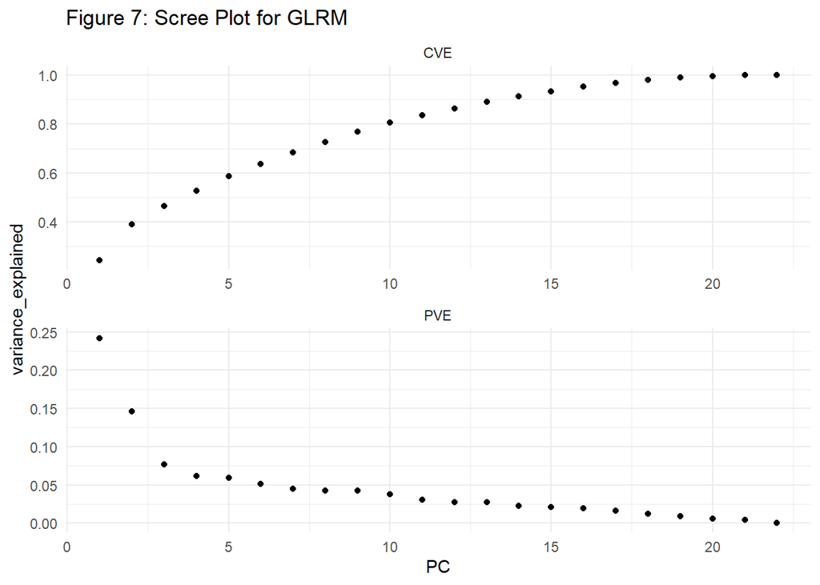

#### 4.2.2 Clustering with Gaussian Mixture Modeling

We use Gaussian Mixture Modeling (GMM) for our next clustering step. Instead of measuring the distance from each tract to a centroid, GMM models each cluster as a multivariate normal distribution, meaning each cluster has its own center and its own shape, capturing the spread and correlation structure of the tracts within it. Tracts that are close to the center of a cluster’s distribution are more likely to belong to it; tracts far from the center are less likely.

GMM also produces soft assignments rather than hard ones. Rather than assigning each tract definitively to a single cluster, GMM estimates the probability that each tract belongs to each cluster. These probabilities (called responsibilities) sum to one for each tract.

To select the number of clusters, we use the Bayesian Information Criterion (BIC). BIC works by balancing model fit against model complexity. A model with more clusters will always fit the data better, but BIC penalizes the additional parameters required, steering us toward solutions that are as simple as possible while still capturing meaningful structure in the data. Figure 8 shows the optimal number of clusters at 8 using BIC. However, for comparison to the PCA, we will choose 5 clusters which eases interpretation.

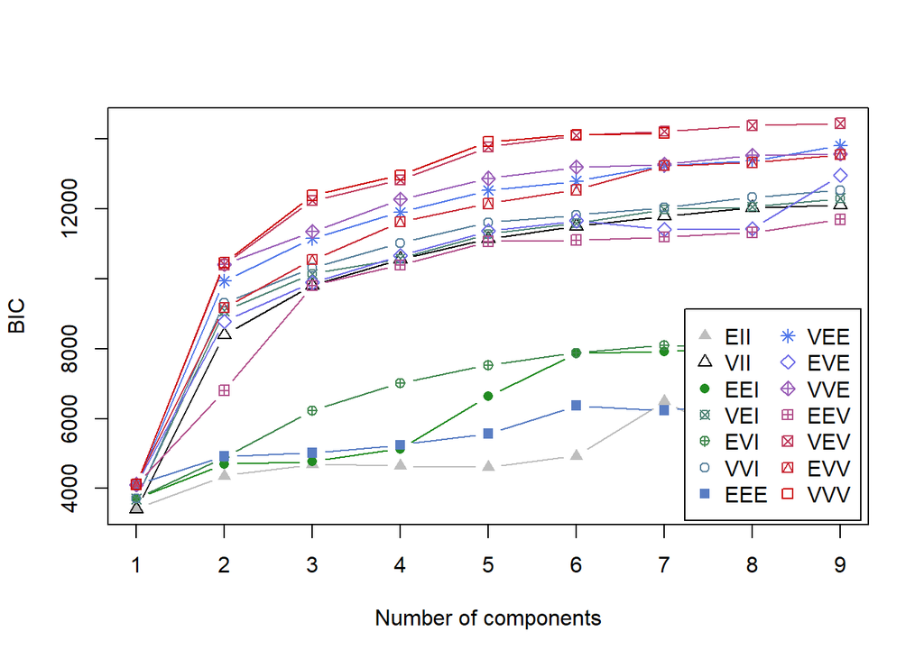

## 5. Results

### 5.1 PCA + K-Means

To label each cluster, we calculated the mean value of a set of key variables across all tracts within each cluster. We focused on median income, median_rent, bachelor’s degree share, percentage white, percentage hispanic, percentage below poverty line, and food and beverage place count. These variables were the seven most important in the first principal component. We then used these cluster means to characterize each group and assign it a label. The five clusters each tell a different story about what kind of neighborhood they represent. Cluster 2 appears to represent the most economically vulnerable census tracts, with the lowest median income ($40,844) and rent ($1,260), as well as the highest poverty rate (36.2%), while also having relatively few food and beverage third places (1.53 places). In contrast, Cluster 5 reflects the most affluent tracts, marked by the highest income ($159,107), rent ($2,953), educational attainment (40.5%), and by far the greatest concentration of food and beverage third places (22.6 places). The remaining clusters occupy intermediate positions, with varying combinations of demographic composition and economic resources. Overall, the results suggest that more advantaged neighborhoods tend to host a higher density of food and beverage third places, while lower-income, higher-poverty areas have more limited access to these social and commercial spaces.

### 5.2 GLRM + GMM

Analysis of our second clustering method further distinguishes neighborhood types by focusing on the percentage of renters, the number of parks, the change in rent, median rent, change in income, change in the poverty rate, and median home value. Similar to the PCA + K-means analysis, clear differences emerge across classes in terms of economic conditions and spatial amenities. Class 2 appears to represent rapidly transforming neighborhoods, characterized by the highest renter share (89.3%), substantial rent growth (10.4%), and the strongest increase in neighborhood income (21.8%), alongside high park availability (0.913). Class 4 reflects the most expensive housing markets, with the highest median rent ($2,594) and home values ($1,249,079), suggesting established high-value areas rather than emerging ones. The remaining classes exhibit more moderate levels of housing costs, park access, and socioeconomic change, indicating relative stability. Together, these findings show that neighborhood disparities are shaped not only by demographic and housing characteristics, but also third-place amenities.

## Bibliography

Center for New York City Affairs. “While the Top Three Percent of Wage Earners Get Richer, New York City’s Low Wage Workers Risk Greater Poverty.” 2024. https://www.centernyc.org/reports-briefs/while-the-top-three-percent-of-wage-earners-get-richer-new-york-citys-low-wage-workers-risk-greater-poverty

New York City Comptroller. “The Racial Wealth Gap in New York.” December 6, 2023. https://comptroller.nyc.gov/reports/the-racial-wealth-gap-in-new-york/

New York Department of Education (DOE). (2024). School Point Locations [Data set]. NYC Open Data. https://data.cityofnewyork.us/Education/School-Point-Locations/jfju-ynrr/about_data

New York Police Department (NYPD). (2024). NYPD Arrests Data (Historic) [Data set]. NYC Open Data. https://data.cityofnewyork.us/Public-Safety/NYPD-Arrests-Data-Historic-/8h9b-rp9u/about_data

Scally, Corianne Payton, Amanda Gold, Yipeng Su, Jorge Morales-Burnett, Eric Burnstein, and Patrick Spauster. “Reenvisioning Rural America: How to Invest in the Strengths and Potential of Rural Communities.” 2021. https://reenvisioning-rural-america.urban.org/

Third Place Index. (2024). Third Place Index: Measuring Community Gathering Space Access in the US [Data set]. https://thirdplaceindex.org/

U.S. Census Bureau. American Community Survey 5-Year Estimates, 2018–2022 and 2020–2024. Accessed via Census Bureau API using tidycensus in R.

Zewdie, Hiwot Y., Jamaica R. Robinson, Marc A. Adams, Anjum Hajat, Jana A. Hirsch, Brian E. Saelens, and Stephen J. Mooney. “A Tale of Many Neighborhoods: Latent Profile Analysis to Derive a National Neighborhood Typology for the US.” Health & Place 86 (March 2024): 103209. https://pubmed.ncbi.nlm.nih.gov/38408408/